# 18048introduction and homework

18048

2019-01-18

## Overview

**StatComp18048** is a simple R package developed to finish the final work of the class of Statistic Computing. Three functions are considered, namely, *Rray* (generate random numbers using a rayleigh-distribution sampler) and *rbetA* (generate random numbers using a beta-distribution sampler) and *table2*(construct a list to statistic the frequency.

The source R code for *RraY* is as follows:

```r
function(m,sigma){
  x<-numeric(m)
  u<-runif(m/2)#use inverse transformation method to generate
  v<-1-u #antithetic variables#
  u<-c(u,v)
  x<-sqrt(-2*(sigma^2)*log(1-u))#intagrate the Rayleigh density function to get the cdf#
  return(x)
}
```

The source R code for *rbetA* is as follows:

```r
function(n,a,b){
   j<-k<-0
   y<-numeric(n)
   while(k<n){
     u<-runif(1)
     j<-j+1
     x<-runif(1)
     if(x^(a-1)*(1-x)^(b-1)>u){
       k<-k+1
       y[k]<-x
     }
   }
   return(y)
}
```

The source R code for *table2* is as follows:

```r
function(x, y) {
  x_val <- unique(x)
  y_val <- unique(y)
  mat <- matrix(0L, length(x_val), length(y_val))
  for (i in seq_along(x)) {
    mat[which(x_val == x[[i]]), which(y_val == y[[i]])] <-
      mat[which(x_val == x[[i]]),  which(y_val == y[[i]])] + 1L
  }
  dimnames <- list(x_val, y_val)
  names(dimnames) <- as.character(as.list(match.call())[-1])  # R has names for dimnames... :/
  tab <- array(mat, dim = dim(mat), dimnames = dimnames)
  class(tab) <- "table"
  tab
}
```

## Example No.1 from Page32

```r
x<-1:4
y<-rep(1,4)
z<-x+y
z
```

```
## [1] 2 3 4 5
```

```r
x<-1:4
y<-1:2
z<-x+y
z
```

```
## [1] 2 4 4 6
```

```r
x <- 1:4
a<-10
z<-a*x
z
```

```
## [1] 10 20 30 40
```

## Example No.2 from Page34

```r
m1<-matrix(1,nr=2,nc=2)
m2<-matrix(2,nr=2,nc=2)
rbind(m1,m2)
```

```
##      [,1] [,2]
## [1,]    1    1
## [2,]    1    1
## [3,]    2    2
## [4,]    2    2
```

```r
cbind(m1,m2)
```

```
##      [,1] [,2] [,3] [,4]
## [1,]    1    1    2    2
## [2,]    1    1    2    2
```

```r
rbind(m1,m2)%*%cbind(m1,m2)
```

```
##      [,1] [,2] [,3] [,4]
## [1,]    2    2    4    4
## [2,]    2    2    4    4
## [3,]    4    4    8    8
## [4,]    4    4    8    8
```

```r
cbind(m1,m2)%*%rbind(m1,m2)
```

```
##      [,1] [,2]
## [1,]   10   10
## [2,]   10   10
```

## Example No.3 from Page40

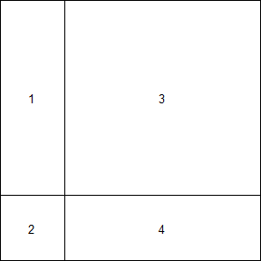

```r
m <- matrix(1:4,2,2)
layout(m,widths=c(1,3),heights=c(3,1))
layout.show(4)
```

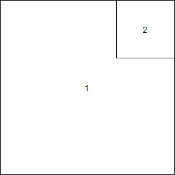

```r
m<-matrix(c(1,1,2,1),2,2)
layout(m,widths=c(2,1),heights=c(1,2))
layout.show(2)
```

## Exercises 3.5

Generate a sample of size 1000 from the distribution of x by the inverse transform method

```r
#Inverse transform method#
x<-c(0,1,2,3,4);p<-c(0.1,0.2,0.2,0.2,0.3)
cp<-cumsum(p);m<-1e3;r<-numeric(m)
r<-x[findInterval(runif(m),cp)+1]
ct1<-as.vector(table(r));
table(r);#frequency table of sample#
```

```
## r
##   0   1   2   3   4
##  90 210 222 203 275
```

```r
ct1/sum(ct1)/p#relative frequency table#
```

```
## [1] 0.9000000 1.0500000 1.1100000 1.0150000 0.9166667
```

```r
#R sample function#
y<-sample(0:4,size=1000,replace=TRUE,prob=c(0.1,0.2,0.2,0.2,0.3))
ct2<-as.vector(table(y));
table(y);#frequency table of sample#
```

```
## y
##   0   1   2   3   4
##  83 202 211 195 309
```

```r
ct2/sum(ct2)/p#relative frequency table#
```

```
## [1] 0.830 1.010 1.055 0.975 1.030
```

## Exercises 3.7

1.Write the function??  
to generate arandom sample of size nfrom the Beta(a,b) distribution by the acceptance-rejection method  
2.Generation:  
a random sample of size 1000 from Beta(3,2) distribution  
3.Graph  
graph the histogram of the sample with the theoretical Beta(3,2) denisy superimposed

```r
#1.Write the function#
g<-function(n,a,b){
    j<-k<-0;y<-numeric(n)
    while(k<n){
      u<-runif(1)
      j<-j+1
      x<-runif(1)
      if(x^(a-1)*(1-x)^(b-1)>u){
        k<-k+1
        y[k]<-x
      }
    }
    return(y)
}
#2.Generation#
x<-g(1000,3,2)#a random sample of size 1000 from Beta(3,2) distribution#
head(x,n=50L)#print the head 50 for example#
```

```
##  [1] 0.9464127 0.9133900 0.5663725 0.6069080 0.6634742 0.5252730 0.8402900
##  [8] 0.4833499 0.6151195 0.5079895 0.7289562 0.2867133 0.8117161 0.8721102
## [15] 0.6623780 0.4914108 0.3874405 0.4546744 0.5200578 0.3380131 0.3047189
## [22] 0.5505617 0.5253127 0.7794274 0.6598202 0.5167062 0.6135800 0.6669220
## [29] 0.5125243 0.3534025 0.2076299 0.1642643 0.8148727 0.4960964 0.9555615
## [36] 0.7161464 0.7305028 0.6405542 0.6279667 0.5466678 0.7238120 0.6327260
## [43] 0.7730762 0.4984093 0.5568960 0.6295239 0.5263352 0.6201730 0.5459558
## [50] 0.4690163
```

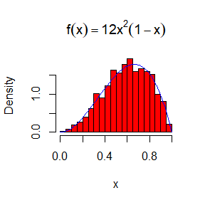

```r
#3.Graph#
hist(x,prob=TRUE,xlab="x",breaks=20,ylab="Density",col="red",main=expression(f(x)==12*x^2*(1-x)))#the histogram of the sample #
z<-seq(0,1,0.01)
lines(z,12*z^2*(1-z),col="blue")#the theoretical Beta(3,2) denisy superimposed#
```

## Exercises 3.12

Simulate a continous Exponential-Gamma mixture.

```r
mix<-function(n,r,beta){
  lambda<-rgamma(n,r,beta)#generate paramete lambda#
  x<-rexp(n,lambda)#generate the mixture#
  return(x)
}
x<-mix(1000,4,2)
head(x,n=50L)#print the head 50 for example#
```

```
##  [1] 0.478629799 0.963011958 0.429821267 0.491795384 0.341891926
##  [6] 0.838136296 1.531382173 0.873349896 0.383786026 0.949339304
## [11] 0.382797549 0.891327861 0.309875487 0.654183796 0.197141014
## [16] 0.720906552 0.989366317 0.153222933 0.558195945 0.089111479
## [21] 1.817400571 1.091227581 0.783008901 0.979747831 0.482482067
## [26] 0.769200290 0.109435593 2.531727640 0.469012181 0.373962035
## [31] 0.084993970 0.039031961 1.623150057 0.051201289 0.042224012
## [36] 1.138183053 1.546262036 0.122036581 0.607811192 0.630416347
## [41] 0.604872578 2.055526545 0.342273565 0.719162763 0.063782445
## [46] 1.240366880 0.732779595 1.112194219 0.003115468 0.317177853
```

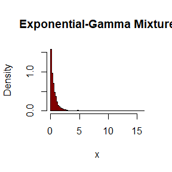

```r
hist(x,prob=TRUE,breaks=60,col="red",main="Exponential-Gamma Mixture")#graph#
```

## Exercises 5.4

the pdf of B(3,3) is x^2*(1-x)^2/B(3,3)

```r
f<-function(x){
 m<-1e4;t<-runif(m,min=0,max=x)#t follows uniform distribution#
 cd<-mean(30*x*(t^2)*((1-t)^2))#use the pdf of B(3,3) to get the conditional expectation as the estimation#
 return(cd)
}
est<-matrix(0,2,9) #compare the generation function and pbeta function#
for(i in 1:9){
  est[1,i]<-pbeta(i/10,3,3)
  est[2,i]<-f(i/10)
}
print(est)
```

```
##            [,1]       [,2]      [,3]      [,4]      [,5]      [,6]
## [1,] 0.00856000 0.05792000 0.1630800 0.3174400 0.5000000 0.6825600
## [2,] 0.00847658 0.05761367 0.1638067 0.3142695 0.5027739 0.6851617
##           [,7]      [,8]      [,9]
## [1,] 0.8369200 0.9420800 0.9914400
## [2,] 0.8488323 0.9352441 0.9952168
```

## Exercises 5.9

sorry to only can write the generation function using the antithetic variables

```r
function(m,sigma){
    x<-numeric(m)
    u<-runif(m/2)#use inverse transformation method to generate
    v<-1-u #antithetic variables#
    u<-c(u,v)
    x<-sqrt(-2*(sigma^2)*log(1-u))#intagrate the Rayleigh density function to get the cdf#
    return(x)
}
```

```
## function(m,sigma){
##     x<-numeric(m)
##     u<-runif(m/2)#use inverse transformation method to generate
##     v<-1-u #antithetic variables#
##     u<-c(u,v)
##     x<-sqrt(-2*(sigma^2)*log(1-u))#intagrate the Rayleigh density function to get the cdf#
##     return(x)
## }
```

## Exercises 5.13

importance function 1–normal distribution pdf importance function 2–Rayleigh distribution pdf from exercise 5.9

```r
m<-10000
theta.hat<-se<-numeric(2)
g<-function(x){x^2/sqrt(2*pi)*exp(-x^2/2)*(x>1)} #g(x)#

x<-rnorm(m) #importance function 1--normal distribution pdf#
fg<-g(x)/((1/sqrt(2*pi))*exp(-x^2/2))
theta.hat[1]<-mean(fg)
se[1]<-sd(fg)

fg2<-function(m,sigma){
    x<-numeric(m)
    u<-runif(m)
    x<-sqrt(-2*(sigma^2)*log(1-u))
    return(x)
}  #importance function 2--Rayleigh distribution pdf from exercise 5.9 #
x<-fg2(m,1)
fg22<-g(x)/(x*exp(-x^2/2))
theta.hat<-mean(fg22)
se[2]<-sd(fg22)
se
```

```
## [1] 1.0993070 0.3585312
```

## Exercises 5.14

Obtain estimate by importance sampling

```r
m<-10000
g<-function(x){(x^2)/sqrt(2*pi)*exp(-x^2/2)*(x>1)}
x<-rnorm(m)
fg<-g(x)/((1/sqrt(2*pi))*exp(-(x^2)/2)) # #importance function --normal distribution pdf#
theta.hat<-mean(fg)
se<-sd(fg)
theta.hat #estimation#
```

```
## [1] 0.3873522
```

# 1

```r
m<-10000
n<-100
gini<-numeric(m)
for(i in 1:m){
  x<-rlnorm(n,meanlog=0,sdlog=1)#standard lognormal distribution#
  xbar<-mean(x)
  xs<-sort(x)
  t<-0
  for(j in 1:n){
    t<-t+(2*j-n-1)*xs[j]/(n*n*xbar)
  }
  gini[i]<-t
}
gini.mean<-mean(gini)
print(gini.mean)#mean#
```

```
## [1] 0.5125983
```

```r
gini.median<-median(gini)
print(gini.median)#median#
```

```
## [1] 0.5109349
```

```r
gini.deciles<-quantile(gini,probs = c(0.1,0.2,0.3,0.4,0.5,0.6,0.7,0.8,0.9))
print(gini.deciles)#deciles#
```

```
##       10%       20%       30%       40%       50%       60%       70%
## 0.4631249 0.4783542 0.4903250 0.5008405 0.5109349 0.5208783 0.5320618
##       80%       90%
## 0.5455156 0.5645514
```

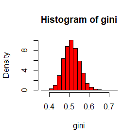

```r
hist(gini,freq = F,col = "red")
```

#2

```r
m<-10000
n<-100
gini<-numeric(m)
for(i in 1:m){
  x<-runif(n) #uniform distribution#
  xbar<-mean(x)
  xs<-sort(x)
  t<-0
  for(j in 1:n){
    t<-t+(2*j-n-1)*xs[j]/(n*n*xbar)
  }
  gini[i]<-t
}
gini.mean<-mean(gini)
print(gini.mean)#mean#
```

```
## [1] 0.3311883
```

```r
gini.median<-median(gini)
print(gini.median)#median#
```

```
## [1] 0.331147
```

```r
gini.deciles<-quantile(gini,probs = c(0.1,0.2,0.3,0.4,0.5,0.6,0.7,0.8,0.9))
print(gini.deciles)#deciles#
```

```
##       10%       20%       30%       40%       50%       60%       70%
## 0.3001351 0.3110728 0.3183201 0.3244523 0.3311470 0.3370536 0.3435045
##       80%       90%
## 0.3512885 0.3628091
```

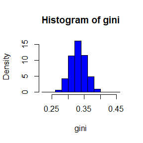

```r
hist(gini,freq = F,col = "blue")
```

```r
set.seed(2)
m<-500
n<-100
gini<-numeric(m)
for(i in 1:m){
  x<-rlnorm(n,meanlog=0,sdlog=1)
  xbar<-mean(x)
  xs<-sort(x)
  t<-0
  for(j in 1:n){
    t<-t+(2*j-n-1)*xs[j]/(n*n*xbar)
  }
  gini[i]<-t
}
mu<-mean(gini)
sigma<-sqrt(sd(gini)/m)
cv<-qnorm(.975,0,1) #using Central limit theotem to construct the 95% confidence interval ,standard normal distribution #
UCL1<-mu-cv*sigma
UCL2<-mu+cv*sigma
UCL1 #down confidence interval
```

```
## [1] 0.4951122
```

```r
UCL2 #up confidence interval #
```

```
## [1] 0.529998
```

```r
l<-2000 #sample from the generation to compute coverge rate#
munew<-numeric(l)
for(k in 1:l){
  m<-100
  n<-50
  gini<-numeric(m)
  for(i in 1:m){
    x<-rlnorm(n,meanlog=0,sdlog=1)
    xbar<-mean(x)
    xs<-sort(x)
    t<-0
    for(j in 1:n){
      t<-t+(2*j-n-1)*xs[j]/(n*n*xbar)
    }
  gini[i]<-t
  }
  munew[k]<-mean(gini)
}
sum((munew<UCL2)&(munew>UCL1))/l #coverage rate#
```

```
## [1] 0.9525
```

## Exercise 3 in P204

Use both for loops and lapply() to fit liner models

```r
attach(mtcars)
formulas<-list(
  mpg~disp,
  mpg~I(1/disp),
  mpg~disp+wt,
  mpg~I(1/disp)+wt
)

#use lapply function
out3_1<-lapply(formulas,lm)
out3_1
```

```
## [[1]]
##
## Call:
## FUN(formula = X[[i]])
##
## Coefficients:
## (Intercept)         disp
##    29.59985     -0.04122
##
##
## [[2]]
##
## Call:
## FUN(formula = X[[i]])
##
## Coefficients:
## (Intercept)    I(1/disp)
##       10.75      1557.67
##
##
## [[3]]
##
## Call:
## FUN(formula = X[[i]])
##
## Coefficients:
## (Intercept)         disp           wt
##    34.96055     -0.01772     -3.35083
##
##
## [[4]]
##
## Call:
## FUN(formula = X[[i]])
##
## Coefficients:
## (Intercept)    I(1/disp)           wt
##      19.024     1142.560       -1.798
```

```r
#use for loops
out3_2<-vector("list",length(formulas))
for(i in seq_along(formulas)){
  out3_2[[i]]<-lm(formulas[[i]],data=mtcars)
}
out3_2
```

```
## [[1]]
##
## Call:
## lm(formula = formulas[[i]], data = mtcars)
##
## Coefficients:
## (Intercept)         disp
##    29.59985     -0.04122
##
##
## [[2]]
##
## Call:
## lm(formula = formulas[[i]], data = mtcars)
##
## Coefficients:
## (Intercept)    I(1/disp)
##       10.75      1557.67
##
##
## [[3]]
##
## Call:
## lm(formula = formulas[[i]], data = mtcars)
##
## Coefficients:
## (Intercept)         disp           wt
##    34.96055     -0.01772     -3.35083
##
##
## [[4]]
##
## Call:
## lm(formula = formulas[[i]], data = mtcars)
##
## Coefficients:
## (Intercept)    I(1/disp)           wt
##      19.024     1142.560       -1.798
```

```r
detach(mtcars)
```

## Exercise 4 in P204

fit the model mpg~disp to each of the bootstrap replicates

```r
attach(mtcars)
bootstraps<-lapply(1:10,function(i){
  rows<-sample(1:nrow(mtcars),rep=TRUE)
  mtcars[rows,]
})

#use lapply function
out4_1<-lapply(seq_along(bootstraps),function(i){lm(mpg~disp,data = bootstraps[[i]])})
out4_1
```

```
## [[1]]
##
## Call:
## lm(formula = mpg ~ disp, data = bootstraps[[i]])
##
## Coefficients:
## (Intercept)         disp
##    31.76330     -0.05036
##
##
## [[2]]
##
## Call:
## lm(formula = mpg ~ disp, data = bootstraps[[i]])
##
## Coefficients:
## (Intercept)         disp
##    30.74390     -0.04732
##
##
## [[3]]
##
## Call:
## lm(formula = mpg ~ disp, data = bootstraps[[i]])
##
## Coefficients:
## (Intercept)         disp
##    30.51984     -0.04562
##
##
## [[4]]
##
## Call:
## lm(formula = mpg ~ disp, data = bootstraps[[i]])
##
## Coefficients:
## (Intercept)         disp
##    30.20927     -0.04184
##
##
```

[output cut: 43 more lines]

```
## lm(formula = mpg ~ disp, data = bootstraps[[i]])
##
## Coefficients:
## (Intercept)         disp
##    32.18131     -0.04906
##
##
## [[10]]
##
## Call:
## lm(formula = mpg ~ disp, data = bootstraps[[i]])
##
## Coefficients:
## (Intercept)         disp
##    27.57557     -0.02914
```

```r
#use for loops
out4_2<-vector("list",length(bootstraps))
for(i in seq_along(bootstraps)){
  out4_2[[i]]<-lm(mpg~disp,data<-bootstraps[[i]])
}
out4_2
```

```
## [[1]]
##
## Call:
## lm(formula = mpg ~ disp, data = data <- bootstraps[[i]])
##
## Coefficients:
## (Intercept)         disp
##    31.76330     -0.05036
##
##
## [[2]]
##
## Call:
## lm(formula = mpg ~ disp, data = data <- bootstraps[[i]])
##
## Coefficients:
## (Intercept)         disp
##    30.74390     -0.04732
##
##
## [[3]]
##
## Call:
## lm(formula = mpg ~ disp, data = data <- bootstraps[[i]])
##
## Coefficients:
## (Intercept)         disp
##    30.51984     -0.04562
##
##
## [[4]]
##
## Call:
## lm(formula = mpg ~ disp, data = data <- bootstraps[[i]])
##
## Coefficients:
## (Intercept)         disp
##    30.20927     -0.04184
##
##
```

[output cut: 43 more lines]

```
## lm(formula = mpg ~ disp, data = data <- bootstraps[[i]])
##
## Coefficients:
## (Intercept)         disp
##    32.18131     -0.04906
##
##
## [[10]]
##
## Call:
## lm(formula = mpg ~ disp, data = data <- bootstraps[[i]])
##
## Coefficients:
## (Intercept)         disp
##    27.57557     -0.02914
```

```r
detach(mtcars)
```

## Exercise 5 in P204

extract Rsquare using the function below

```r
rsq<-function(mod) summary(mod)$r.squared
#exercise 3
req3_1 <- lapply(out3_1, rsq)
req3_2 <- lapply(out3_2, rsq)
print(data.frame(unlist(req3_1),unlist(req3_2)))
```

```
##   unlist.req3_1. unlist.req3_2.
## 1      0.7183433      0.7183433
## 2      0.8596865      0.8596865
## 3      0.7809306      0.7809306
## 4      0.8838038      0.8838038
```

```r
#exercise 4
req4_1 <- lapply(out4_1, rsq)
req4_2 <- lapply(out4_2, rsq)
print(data.frame(unlist(req4_1),unlist(req4_2)))
```

```
##    unlist.req4_1. unlist.req4_2.
## 1       0.8447649      0.8447649
## 2       0.7180675      0.7180675
## 3       0.8087394      0.8087394
## 4       0.7289812      0.7289812
## 5       0.7392200      0.7392200
## 6       0.7364307      0.7364307
## 7       0.5658927      0.5658927
## 8       0.7426655      0.7426655
## 9       0.8066503      0.8066503
## 10      0.5981429      0.5981429
```

## Exercise 3 in P214

Use sapply() and an anonymous function to extract the p-value from every trial

```r
trials <- replicate(100,
                    t.test(rpois(10, 10), rpois(7, 10)),
                    simplify = FALSE)

sapply(trials,function(mod){mod[["p.value"]]},simplify=TRUE)
```

```
##   [1] 0.253694835 0.140699853 0.671177463 0.673787641 0.559702904
##   [6] 0.049383463 0.009949375 0.855585163 0.777797067 0.892612604
##  [11] 0.287924499 0.654189935 0.676828624 0.952488700 0.402954166
##  [16] 0.660217546 0.063185079 0.332191480 0.964871967 0.338209902
##  [21] 0.527181640 0.261636950 0.202368323 0.527706169 0.666842906
##  [26] 0.971225398 0.472232473 0.680012241 0.358313965 0.442759035
##  [31] 0.346402000 0.855679783 0.544368224 0.406388331 0.267102029
##  [36] 0.929767689 0.811852023 0.735985982 0.164602596 0.227720637
##  [41] 0.475775671 0.992951068 0.945236163 0.163566167 0.113430002
##  [46] 1.000000000 0.509952289 0.839981111 0.847389940 0.153415901
##  [51] 0.519338120 0.638989146 0.887789526 0.007161573 0.769095939
##  [56] 0.637124111 0.670966765 0.043882959 0.055922339 0.448472751
##  [61] 0.993288289 0.294597741 0.738805182 0.361318879 0.063417216
##  [66] 0.135574045 0.797909687 0.645807517 0.863965960 0.406068553
##  [71] 0.439292236 0.857419535 0.102281994 0.872942110 0.870656742
##  [76] 0.315827299 0.283051287 0.251386465 0.590635993 0.296940901
##  [81] 0.124287447 0.652853191 0.958402302 0.146682479 0.672603593
##  [86] 0.992567429 0.494867017 0.385152323 0.581952337 0.692489372
##  [91] 0.022995729 0.324138491 0.632536705 0.503152365 0.397260058
##  [96] 0.697154382 0.469019390 0.183155648 0.651348322 0.599328298
```

## Exercise 6 in P214

implement a combination of Map() and vapply()to create an lapply() variant

```r
# the example is make the data normalized (the value divide by the colmean)
# use Map and vapply to solve
data <- matrix(rnorm(20, 0, 10), nrow = 4)
x <- as.data.frame(data)
answer1 <- Map("/",x,vapply(x,mean,c(1)))

# use the lapply with an anonymous function to solve
answer2 <- lapply(x,function(data){data/(mean(data))})
print(data.frame(unlist(answer1),unlist(answer2)))
```

```
##     unlist.answer1. unlist.answer2.
## V11      1.93191393      1.93191393
## V12      0.84145291      0.84145291
## V13      0.45140514      0.45140514
## V14      0.77522802      0.77522802
## V21      0.03582964      0.03582964
## V22      0.92240568      0.92240568
## V23      5.04844255      5.04844255
## V24     -2.00667788     -2.00667788
## V31     -1.08009986     -1.08009986
## V32      4.63476922      4.63476922
## V33      2.56441075      2.56441075
## V34     -2.11908011     -2.11908011
## V41     -6.58071529     -6.58071529
## V42     -5.79076943     -5.79076943
## V43      6.59310018      6.59310018
## V44      9.77838455      9.77838455
## V51      0.04143513      0.04143513
## V52     -0.78359905     -0.78359905
## V53      4.78691165      4.78691165
## V54     -0.04474773     -0.04474773
```

## Exercise 8.1

Inplement the two-sample Cramer-von Mises test for equal distributions as a permutation test

```r
library("nortest")
set.seed(1)
attach(chickwts)
x<-sort(as.vector(weight[feed=="soybean"]))
y<-sort(as.vector(weight[feed=="linseed"]))
detach(chickwts)
z<-c(x,y)#pooled sample#
R<-999#replicate number#
K<-1:length(z)
D<-numeric(R)
CM<-function(x,y){#compute statistic of Cramer-von Mises
  ecdfx<-ecdf(x)
  ecdfy<-ecdf(y)
  l_x<-length(x)
  l_y<-length(y)
  sum1<-sum((ecdfx(x)-ecdfy(x))^2)
  sum2<-sum((ecdfx(y)-ecdfy(y))^2)
  w<-l_x*l_y/(l_x+l_y)^2*(sum1+sum2)
  return(w)
}
D0<-CM(x,y)
for(i in 1:R){
  k<-sample(K,size=length(x),replace=F)
  x1<-z[k]
  y1<-z[-k]
  D[i]<-CM(x1,y1)
}
p<-mean(c(D0,D)>=D0)
print(p)
```

```
## [1] 0.421
```

## Exercise in class

```r
library(RANN)
library(boot)
library(energy)
library(Ball)
```

```r
library(ggplot2)
m<-30#time to loop
k<-3
p<-2
n1<-n2<-50
R<-999#bd.test replication number
n<-n1+n2
N=c(n1,n2)
Tn<-function(z,ix,sizes,k){
  n1<-sizes[1]
  n2<-sizes[2]
  n<-n1+n2
  if(is.vector(z)) z<-data.frame(z,0)
  z<-z[ix,]
  NN<-nn2(data=z,k=k+1)
  block1<-NN$nn.idx[1:n1,-1]
  block2<-NN$nn.idx[(n1+1):n,-1]
  i1<-sum(block1<n1+.5);i2<-sum(block2>n1+.5)
  (i1+i2)/(k*n)
}
eqdist.nn<-function(z,sizes,k){
  boot.obj<-boot(data=z,statistic = Tn,R=R,sim="permutation",sizes=sizes,k=k)
  ts<-c(boot.obj$t0,boot.obj$t)
  p.value<-mean(ts>=ts[1])
  list(statistic=ts[1],p.value=p.value)
}#NN
p.values<-matrix(NA,m,3)
for(i in 1:m){
  x<-matrix(rnorm(n1*p,sd=1),ncol=p)#unequal variances
  y<-matrix(rnorm(n2*p,sd=1.4),ncol=p)
  z<-rbind(x,y)
  p.values[i,1]<-eqdist.nn(z,N,k)$p.value#NN
  p.values[i,2]<-eqdist.etest(z,size=N,R=R)$p.value#in the energy package
  p.values[i,3]<-bd.test(x=x,y=y,R=999,seed=i)$p.value#BAll Divergence in the ball package
}
alpha<-0.1#confidence level
pow<-apply(p.values<alpha,2,mean)#compute the number of p.values which is less than 0.1 in each column
print(pow)
```

```
## [1] 0.3333333 0.3666667 0.8666667
```

# Unequal variance and unequal expectations

```r
for(i in 1:m){
  x<-matrix(rnorm(n1*p,mean=0.4,sd=1),ncol=p)#uniqual variances and unequal expectations
  y<-matrix(rnorm(n2*p,mean=0,sd=1.4),ncol=p)
  z<-rbind(x,y)
  p.values[i,1]<-eqdist.nn(z,N,k)$p.value
  p.values[i,2]<-eqdist.etest(z,size=N,R=R)$p.value
  p.values[i,3]<-bd.test(x=x,y=y,R=999,seed=i)$p.value
}
alpha<-0.1
pow<-apply(p.values<alpha,2,mean)
print(pow)
```

```
## [1] 0.4333333 0.7666667 0.9000000
```

# Non-normal distribution with 1 df and bimodel distribution

```r
for(i in 1:m){
  x<-matrix(rt(n1*p,df=1),ncol=p)#t distribution
  y<-matrix(rnorm(n2*p,sd=sample(c(1,1.3),size=n2*p,prob=c(0.5,0.5),replace=T)),ncol=p)#bimodel distuibution
  z<-rbind(x,y)
  p.values[i,1]<-eqdist.nn(z,N,k)$p.value
  p.values[i,2]<-eqdist.etest(z,size=N,R=R)$p.value
  p.values[i,3]<-bd.test(x=x,y=y,R=999,seed=i)$p.value
}
alpha<-0.01
pow<-apply(p.values<alpha,2,mean)
print(pow)
```

```
## [1] 0.2666667 0.8666667 1.0000000
```

# Unbalanced samples

```r
n1<-50
n2<-5
n<-n1+n2
N=c(n1,n2)
for(i in 1:m){
  x<-matrix(rnorm(n1*p,mean=1),ncol=p)#100 samples
  y<-matrix(rnorm(n2*p,mean=2),ncol=p)#10 samples
  z<-rbind(x,y)
  p.values[i,1]<-eqdist.nn(z,N,k)$p.value
  p.values[i,2]<-eqdist.etest(z,size=N,R=R)$p.value
  p.values[i,3]<-bd.test(x=x,y=y,R=999,seed=i)$p.value
}
alpha<-0.1
pow<-apply(p.values<alpha,2,mean)
print(pow)
```

```
## [1] 0.3666667 0.8333333 0.6333333
```

## Exercise 9.3

Use the Metropolis-Hastings sampler to generate random variables from a standard cauchy distribution

```r
library(tidyverse)
set.seed(1)
m<-20000#samples number
x<-numeric(m)#to store the samples
x[1]<-runif(1)#the first sample
u<-runif(m)
standard_Cauchy<-function(x){
  return(1/(pi*(1+x^2)))
}
for(i in 1:m){
  proposal<-x[i]+runif(1,min = -1,max = 1)
  accept<-runif(1)<standard_Cauchy(proposal)/standard_Cauchy(x[i])
  x[i+1]<-ifelse(accept==T,proposal,x[i])
}
x<-x[1001:m]
index<-1001:m
quantile(x,probs = seq(0.1,0.9,0.1))
```

```
##         10%         20%         30%         40%         50%         60%
## -2.25904777 -1.09864404 -0.57161128 -0.21479782  0.09794967  0.44473952
##         70%         80%         90%
##  0.86198430  1.57003310  3.83295922
```

```r
qcauchy(seq(0.1,0.9,0.1),loc=0,scale=1)
```

```
## [1] -3.0776835 -1.3763819 -0.7265425 -0.3249197  0.0000000  0.3249197
## [7]  0.7265425  1.3763819  3.0776835
```

## Exercise9.6

Estimate the posterior distribution of theta given the observed sample

```r
set.seed(1)
m<-5000#lengths of the chain
w<-0.25#width of the uniform support set
u<-runif(m)#for accept/reject step
v<-runif(m,-w,w)#proposal distribution
group<-c(125,18,20,34)
x<-numeric(m)#the chain
prob<-function(theta,group){
  if(theta<0||theta>=0.8)
    return(0)
  return((1/2+theta/4)^group[1]*((1-theta)/4)^group[2]*((1-theta)/4)^group[3]*(theta/4)^group[4])
}
x[1]<-0.4#initialize form 0.4
for(i in 2:m){
  theta<-x[i-1]+v[i]
  if(u[i]<=prob(theta,group)/prob(x[i-1],group))
    x[i]<-theta
  else
    x[i]<-x[i-1]
}
index<-1001:m#discard the first thousand sample
theta_hat<-mean(x[index])
print(theta_hat)
```

```
## [1] 0.6211224
```

## Exercise 9.6

Estimate the posterior distribution of theta given the observed sample.

```r
set.seed(12345)
group<-c(125,18,20,34)
k<-4#number if chains to generate
N<-5000#length of the chain
b<-500#burn-in length
Gelman.Robin<-function(psi){
  psi<-as.matrix(psi)
  n<-ncol(psi)
  k<-nrow(psi)
  psi.means<-rowMeans(psi)#row means
  B<-n*var(psi.means)#between variance est.
  psi.w<-apply(psi,1,"var")#within variances
  W<-mean(psi.w)#within est.
  v.hat<-W*(n-1)/n+(B/n)#uppervariance est.
  r.hat<-v.hat/W#G_R statistic
  return(r.hat)
}
prob<-function(theta,group){
  if(theta<0||theta>=0.9)
    return(0)
  return((1/2+theta/4)^group[1]*((1-theta)/4)^group[2]*((1-theta)/4)^group[3]*(theta/4)^group[4])
}
Chain<-function(group,N,X1){
  x<-numeric(N)
  x[1]<-X1#initialize x[1]
  w<-0.25
  u<-runif(N)
  v<-runif(N,-w,w)
  for(i in 2:N){
    theta<-x[i-1]+v[i]
    if(u[i]<=prob(theta,group)/prob(x[i-1],group))
      x[i]<-theta
    else
      x[i]<-x[i-1]
  }
  return(x)
}
#generate the chains
x0<-c(0.2,0.4,0.6,0.8)
X<-matrix(0,nrow=k,ncol=N)
for(i in 1:k) X[i,]<-Chain(group,N,x0[i])
#compute diagnostic statistics
psi<-t(apply(X,1,cumsum))
for(i in 1:nrow(psi)) psi[i,]<-psi[i,]/(1:ncol(psi))
print(Gelman.Robin(psi))
```

```
## [1] 1.028472
```

```r
#plot pso for the four chains
par(mfrow=c(2,2))
par(mfrow=c(1,1))#restore default
#plot the sequence of R-hat statistics
rhat<-rep(0,N)
```

## Exercise 11.4

Find the intersection points A(k) in (0,sqrt(k)) of the two curves for k=4:25,100,500,1000

```r
set.seed(12345)
eps<-.Machine$double.eps^0.25#criterion to judge whether function is near to 0
k<-c(4:25,100,500,1000)#k mentioned in the question
S<-function(k,a){
  return((1-pt(sqrt((a^2*k)/(k+1-a^2)),df=k))-(1-pt(sqrt((a^2*(k-1))/(k-a^2)),df=k-1)))
}#S_k(a)-S_{k-1}(a)
Root<-function(k1){
  a<-seq(0.1,sqrt(k1)-0.1,length=3)
  y<-c(S(k1,a[1]),S(k1,a[2]),S(k1,a[3]))
  while(abs(y[2])>eps){
    if(y[1]*y[2]<0){
      a[3]<-a[2]
      y[3]<-y[2]
    }
    else{
      a[1]<-a[2]
      y[1]<-y[2]
    }
    a[2]<-(a[1]+a[3])/2
    y[2]<-S(k1,a[2])
  }
  result<-list(k1,a[2],y[2])
  return(result)
}
for(i in k){#print the out put of each k
  cat('k:',Root(i)[[1]],'root:',Root(i)[[2]],'value of function:',Root(i)[[3]],'\n')
}
```

```
## k: 4 root: 1.492188 value of function: 2.19293e-06
## k: 5 root: 1.53161 value of function: -2.600727e-05
## k: 6 root: 1.576228 value of function: 0.000107711
## k: 7 root: 1.59038 value of function: 3.14324e-05
## k: 8 root: 1.57849 value of function: -8.553791e-05
## k: 9 root: 1.5875 value of function: -7.580885e-05
## k: 10 root: 1.581139 value of function: -9.644197e-05
## k: 11 root: 1.658312 value of function: 3.993887e-05
## k: 12 root: 1.732051 value of function: 0.0001166009
## k: 13 root: 1.589929 value of function: -6.878761e-05
## k: 14 root: 1.649475 value of function: -4.503052e-06
## k: 15 root: 1.70693 value of function: 3.769164e-05
## k: 16 root: 1.525 value of function: -0.000104609
## k: 17 root: 1.571165 value of function: -6.213979e-05
## k: 18 root: 1.61599 value of function: -3.041938e-05
## k: 19 root: 1.659587 value of function: -6.8282e-06
## k: 20 root: 2.236068 value of function: 0.0001210204
## k: 21 root: 2.291288 value of function: 0.0001079948
## k: 22 root: 2.345208 value of function: 9.578466e-05
## k: 23 root: 2.397916 value of function: 8.454769e-05
## k: 24 root: 2.44949 value of function: 7.434282e-05
## k: 25 root: 2.5 value of function: 6.516662e-05
## k: 100 root: 5 value of function: 1.068744e-09
## k: 500 root: 11.18034 value of function: 0
## k: 1000 root: 15.81139 value of function: 0
```

## Exercise 11.6

compute the cdf of cauchy distribution

```r
theta1<-1;ita1<-0#standard cauchy ditribution
f<-function(x,theta,ita){
  (theta*pi*(1+((x-ita)/theta)^2))^(-1)
}
k<-seq(-30,30,2)
F1<-rep(0,length(k))
for(i in 1:length(k)){
  up<-k[i]
  F1[i]<-integrate(f,lower=-Inf,upper=up,rel.tol = .Machine$double.eps^0.25,theta<-theta1,ita<-ita1)$value
}#integrate function
F2<-pcauchy(k)
F1
```

```
##  [1] 0.01060640 0.01136338 0.01223666 0.01325524 0.01445868 0.01590225
##  [7] 0.01766572 0.01986852 0.02269787 0.02646468 0.03172552 0.03958342
## [13] 0.05256846 0.07797913 0.14758362 0.50000000 0.85241638 0.92202087
## [19] 0.94743154 0.96041658 0.96827448 0.97353532 0.97730213 0.98013148
## [25] 0.98233428 0.98409775 0.98554132 0.98674476 0.98776334 0.98863662
## [31] 0.98939360
```

```r
F2
```

```
##  [1] 0.01060640 0.01136338 0.01223666 0.01325524 0.01445868 0.01590225
##  [7] 0.01766572 0.01986852 0.02269787 0.02646468 0.03172552 0.03958342
## [13] 0.05256846 0.07797913 0.14758362 0.50000000 0.85241638 0.92202087
## [19] 0.94743154 0.96041658 0.96827448 0.97353532 0.97730213 0.98013148
## [25] 0.98233428 0.98409775 0.98554132 0.98674476 0.98776334 0.98863662
## [31] 0.98939360
```

## Question

Let the three alleles be A, B, and O

| Genotype | AA | BB | OO | AO | BO | AB |
| --- | --- | --- | --- | --- | --- | --- |
| Frequency | P2 | Q2 | r2 | 2pr | 2qr | 2pq |
| Count | nAA | nBB | nOO | nAO | nBO | nAB |

Observed data: nA. = nAA + nAO = 28 (A-type), nB. = nBB + nBO = 24 (B-type), nOO = 41 (O-type), nAB = 70 (AB-type).

Use EM algorithm to solve MLE of p and q (consider missing data nAA and nBB).

Record the maximum likelihood values in M-steps, are they increasing?

```r
N=1000
na=28
nb=24
noo=41
nab=70
p=0.6   #initial est. for p
q=0.3
r=0.1
pm=numeric(0)
qm=numeric(0)
rm=numeric(0)
lofm=numeric(0)
lof=function(p,q,r){   #log maximum likelihood values
  return(log(choose(n,naa)*choose(n-naa,nbb)*choose(n-naa-nbb,noo)*choose(nao+nbo+nab,nao)*choose(nbo+nab,nbo))+(nao+nbo+nab)*log(2)+(2*naa+nao+nab)*log(p)+(2*nbb+nbo+nab)*log(q)+(2*noo+nao+nbo)*log(r))
}
for (j in 1:N) {
  naa=round(na*p^2/(p^2+2*p*r))
  nbb=round(nb*q^2/(q^2+2*q*r))
  nao=na-naa
  nbo=nb-nbb
  n=naa+nbb+noo+nao+nbo+nab
  if(abs(p-(2*naa+nao+nab)/2/n)<0.000000001&&abs(q-(2*nbb+nbo+nab)/2/n)<0.000000001&&abs(r-(2*noo+nbo+nao)/2/n)<0.000000001&&j>5) break
  p=(2*naa+nao+nab)/2/n  #update estimation
  q=(2*nbb+nbo+nab)/2/n
  r=(2*noo+nbo+nao)/2/n
  pm=c(pm,p)
  qm=c(qm,q)
  rm=c(rm,r)
  lofm=c(lofm,lof(p,q,r))
}
c(p,q,r)
```

```
## [1] 0.3282209 0.3098160 0.3619632
```

```r
exp(lofm)
```

```
## [1] 6.864600e-29 1.798439e-23 2.908277e-23 2.908277e-23 2.908277e-23
```

```r
attach(mtcars)
formulas<-list(
  mpg~disp,
  mpg~I(1/disp),
  mpg~disp+wt,
  mpg~I(1/disp)+wt
)

#use lapply function
out3_1<-lapply(formulas,lm)
out3_1
```

```
## [[1]]
##
## Call:
## FUN(formula = X[[i]])
##
## Coefficients:
## (Intercept)         disp
##    29.59985     -0.04122
##
##
## [[2]]
##
## Call:
## FUN(formula = X[[i]])
##
## Coefficients:
## (Intercept)    I(1/disp)
##       10.75      1557.67
##
##
## [[3]]
##
## Call:
## FUN(formula = X[[i]])
##
## Coefficients:
## (Intercept)         disp           wt
##    34.96055     -0.01772     -3.35083
##
##
## [[4]]
##
## Call:
## FUN(formula = X[[i]])
##
## Coefficients:
## (Intercept)    I(1/disp)           wt
##      19.024     1142.560       -1.798
```

```r
#use for loops
out3_2<-vector("list",length(formulas))
for(i in seq_along(formulas)){
  out3_2[[i]]<-lm(formulas[[i]],data=mtcars)
}
out3_2
```

```
## [[1]]
##
## Call:
## lm(formula = formulas[[i]], data = mtcars)
##
## Coefficients:
## (Intercept)         disp
##    29.59985     -0.04122
##
##
## [[2]]
##
## Call:
## lm(formula = formulas[[i]], data = mtcars)
##
## Coefficients:
## (Intercept)    I(1/disp)
##       10.75      1557.67
##
##
## [[3]]
##
## Call:
## lm(formula = formulas[[i]], data = mtcars)
##
## Coefficients:
## (Intercept)         disp           wt
##    34.96055     -0.01772     -3.35083
##
##
## [[4]]
##
## Call:
## lm(formula = formulas[[i]], data = mtcars)
##
## Coefficients:
## (Intercept)    I(1/disp)           wt
##      19.024     1142.560       -1.798
```

```r
detach(mtcars)
```

## Exercise 4 in P204

fit the model mpg~disp to each of the bootstrap replicates

```r
attach(mtcars)
bootstraps<-lapply(1:10,function(i){
  rows<-sample(1:nrow(mtcars),rep=TRUE)
  mtcars[rows,]
})

#use lapply function
out4_1<-lapply(seq_along(bootstraps),function(i){lm(mpg~disp,data = bootstraps[[i]])})
out4_1
```

```
## [[1]]
##
## Call:
## lm(formula = mpg ~ disp, data = bootstraps[[i]])
##
## Coefficients:
## (Intercept)         disp
##    27.18917     -0.03496
##
##
## [[2]]
##
## Call:
## lm(formula = mpg ~ disp, data = bootstraps[[i]])
##
## Coefficients:
## (Intercept)         disp
##    28.27433     -0.03751
##
##
## [[3]]
##
## Call:
## lm(formula = mpg ~ disp, data = bootstraps[[i]])
##
## Coefficients:
## (Intercept)         disp
##    29.30162     -0.03752
##
##
## [[4]]
##
## Call:
## lm(formula = mpg ~ disp, data = bootstraps[[i]])
##
## Coefficients:
## (Intercept)         disp
##    31.06115     -0.04546
##
##
```

[output cut: 43 more lines]

```
## lm(formula = mpg ~ disp, data = bootstraps[[i]])
##
## Coefficients:
## (Intercept)         disp
##    28.67018     -0.03834
##
##
## [[10]]
##
## Call:
## lm(formula = mpg ~ disp, data = bootstraps[[i]])
##
## Coefficients:
## (Intercept)         disp
##    30.43755     -0.04429
```

```r
#use for loops
out4_2<-vector("list",length(bootstraps))
for(i in seq_along(bootstraps)){
  out4_2[[i]]<-lm(mpg~disp,data<-bootstraps[[i]])
}
out4_2
```

```
## [[1]]
##
## Call:
## lm(formula = mpg ~ disp, data = data <- bootstraps[[i]])
##
## Coefficients:
## (Intercept)         disp
##    27.18917     -0.03496
##
##
## [[2]]
##
## Call:
## lm(formula = mpg ~ disp, data = data <- bootstraps[[i]])
##
## Coefficients:
## (Intercept)         disp
##    28.27433     -0.03751
##
##
## [[3]]
##
## Call:
## lm(formula = mpg ~ disp, data = data <- bootstraps[[i]])
##
## Coefficients:
## (Intercept)         disp
##    29.30162     -0.03752
##
##
## [[4]]
##
## Call:
## lm(formula = mpg ~ disp, data = data <- bootstraps[[i]])
##
## Coefficients:
## (Intercept)         disp
##    31.06115     -0.04546
##
##
```

[output cut: 43 more lines]

```
## lm(formula = mpg ~ disp, data = data <- bootstraps[[i]])
##
## Coefficients:
## (Intercept)         disp
##    28.67018     -0.03834
##
##
## [[10]]
##
## Call:
## lm(formula = mpg ~ disp, data = data <- bootstraps[[i]])
##
## Coefficients:
## (Intercept)         disp
##    30.43755     -0.04429
```

```r
detach(mtcars)
```

## Exercise 5 in P204

extract Rsquare using the function below

```r
rsq<-function(mod) summary(mod)$r.squared
#exercise 3
req3_1 <- lapply(out3_1, rsq)
req3_2 <- lapply(out3_2, rsq)
print(data.frame(unlist(req3_1),unlist(req3_2)))
```

```
##   unlist.req3_1. unlist.req3_2.
## 1      0.7183433      0.7183433
## 2      0.8596865      0.8596865
## 3      0.7809306      0.7809306
## 4      0.8838038      0.8838038
```

```r
#exercise 4
req4_1 <- lapply(out4_1, rsq)
req4_2 <- lapply(out4_2, rsq)
print(data.frame(unlist(req4_1),unlist(req4_2)))
```

```
##    unlist.req4_1. unlist.req4_2.
## 1       0.7371990      0.7371990
## 2       0.6644658      0.6644658
## 3       0.6607375      0.6607375
## 4       0.7185377      0.7185377
## 5       0.7669859      0.7669859
## 6       0.7132957      0.7132957
## 7       0.6390637      0.6390637
## 8       0.7653332      0.7653332
## 9       0.6666068      0.6666068
## 10      0.7716368      0.7716368
```

## Exercise 3 in P214

Use sapply() and an anonymous function to extract the p-value from every trial

```r
trials <- replicate(100,
                    t.test(rpois(10, 10), rpois(7, 10)),
                    simplify = FALSE)

sapply(trials,function(mod){mod[["p.value"]]},simplify=TRUE)
```

```
##   [1] 0.338443111 0.852765429 0.781349109 0.151721924 0.335095063
##   [6] 0.759271506 0.531588304 0.957602819 0.939485760 0.528406312
##  [11] 0.430907535 0.678383079 0.655262161 0.026146802 0.775996081
##  [16] 0.812849163 0.519675065 0.118122968 0.485758517 0.005298892
##  [21] 0.115965642 0.819319421 0.969135765 0.947433994 0.677562173
##  [26] 0.517073171 0.400585609 0.275367376 0.600126061 0.694819314
##  [31] 0.739291732 0.398860784 0.697815689 0.101848024 0.216758746
##  [36] 0.575520510 0.896505778 0.322384545 0.279686405 0.238148815
##  [41] 0.016675099 0.577138322 0.668157426 0.537127319 0.212280061
##  [46] 0.234082880 0.970302631 0.541851278 0.045886570 0.355407749
##  [51] 0.139355215 0.089158997 0.740480826 0.387429926 0.758233652
##  [56] 0.869824235 0.765606023 0.192362103 0.511689403 0.253709961
##  [61] 0.180891022 1.000000000 0.816868128 0.625198811 0.762913745
##  [66] 0.913065056 0.925545632 0.124792468 0.157547735 0.110249299
##  [71] 0.927394049 0.898188991 0.252664264 0.438047103 0.729343933
##  [76] 0.403799654 0.529103731 0.767609697 0.106577751 0.281554539
##  [81] 0.337777262 0.019054003 0.676979946 0.793156682 0.805936085
##  [86] 0.079460186 0.479409278 0.270959814 0.016806041 0.064464821
##  [91] 0.480312417 0.168643179 0.679077127 0.085490497 0.512183187
##  [96] 0.124252584 0.679393355 0.209574151 0.432847923 0.456101204
```

## Exercise 6 in P214

implement a combination of Map() and vapply()to create an lapply() variant

```r
# the example is make the data normalized (the value divide by the colmean)
# use Map and vapply to solve
data <- matrix(rnorm(20, 0, 10), nrow = 4)
x <- as.data.frame(data)
answer1 <- Map("/",x,vapply(x,mean,c(1)))

# use the lapply with an anonymous function to solve
answer2 <- lapply(x,function(data){data/(mean(data))})
print(data.frame(unlist(answer1),unlist(answer2)))
```

```
##     unlist.answer1. unlist.answer2.
## V11      -5.0223994      -5.0223994
## V12      18.6789896      18.6789896
## V13      10.4369659      10.4369659
## V14     -20.0935561     -20.0935561
## V21       2.4783703       2.4783703
## V22      -0.2472912      -0.2472912
## V23       1.3463415       1.3463415
## V24       0.4225794       0.4225794
## V31       1.0070801       1.0070801
## V32      -0.7375323      -0.7375323
## V33       5.4615504       5.4615504
## V34      -1.7310983      -1.7310983
## V41      -2.7796231      -2.7796231
## V42      -0.5191089      -0.5191089
## V43       2.2793520       2.2793520
## V44       5.0193799       5.0193799
## V51       1.1099954       1.1099954
## V52       1.2237145       1.2237145
## V53       1.3391371       1.3391371
## V54       0.3271530       0.3271530
```

## Exercise 4 in P365

Make a faster version of chisq.test() that only computes the chi-square test statistic when the input is two numeric vectors with no missing values.

```r
expected <- function(colsum, rowsum, total) {
  (colsum / total) * (rowsum / total) * total
}
chisq.stat <- function(observed, expected) {
  ((observed - expected) ^ 2) / expected
}#compute the pearson's chisquare test statistic
```

## Exercise 5 in P365

Can you make a faster version of table() for the case of an input of two integer vectors with no missing values?

```r
library(microbenchmark)
table2 <- function(x, y) {
  x_val <- unique(x)
  y_val <- unique(y)
  mat <- matrix(0L, length(x_val), length(y_val))
  for (i in seq_along(x)) {
    mat[which(x_val == x[[i]]), which(y_val == y[[i]])] <-
      mat[which(x_val == x[[i]]),  which(y_val == y[[i]])] + 1L
  }
  dimnames <- list(x_val, y_val)
  names(dimnames) <- as.character(as.list(match.call())[-1])  # R has names for dimnames... :/
  tab <- array(mat, dim = dim(mat), dimnames = dimnames)
  class(tab) <- "table"
  tab
}
a <- c(2,3,4)#an example
identical(table(a, a), table2(a, a))
```

```
## [1] TRUE
```

```r
microbenchmark::microbenchmark(table(a, a), table2(a, a))
```

```
## Unit: microseconds
##          expr     min       lq      mean  median      uq     max neval
##   table(a, a) 148.923 161.0255 187.91386 169.436 192.821 548.102   100
##  table2(a, a)  39.795  42.6670  49.57559  47.795  53.128  91.077   100
```